# Quantium Virtual Internship - Retail Strategy and Analytics

maurice odhiambo

2025-01-18

# Retail Strategy and Analytics

## Data exploration

### import dataset

```r
purchase_behaviour<- read.csv("QVI_purchase_behaviour (1).csv")
transaction_data<-read_excel("QVI_transaction_data (1).xlsx")
```

### summary

#### purchase behaviour.

```r
str(purchase_behaviour)
```

```
## 'data.frame':    72637 obs. of  3 variables:
##  $ LYLTY_CARD_NBR  : int  1000 1002 1003 1004 1005 1007 1009 1010 1011 1012 ...
##  $ LIFESTAGE       : chr  "YOUNG SINGLES/COUPLES" "YOUNG SINGLES/COUPLES" "YOUNG FAMILIES" "OLDER SINGLES/COUPLES" ...
##  $ PREMIUM_CUSTOMER: chr  "Premium" "Mainstream" "Budget" "Mainstream" ...
```

#### transactioh data

```r
str(transaction_data)
```

```
## tibble [264,836 × 8] (S3: tbl_df/tbl/data.frame)
##  $ DATE          : num [1:264836] 43390 43599 43605 43329 43330 ...
##  $ STORE_NBR     : num [1:264836] 1 1 1 2 2 4 4 4 5 7 ...
##  $ LYLTY_CARD_NBR: num [1:264836] 1000 1307 1343 2373 2426 ...
##  $ TXN_ID        : num [1:264836] 1 348 383 974 1038 ...
##  $ PROD_NBR      : num [1:264836] 5 66 61 69 108 57 16 24 42 52 ...
##  $ PROD_NAME     : chr [1:264836] "Natural Chip        Compny SeaSalt175g" "CCs Nacho Cheese    175g" "Smiths Crinkle Cut  Chips Chicken 170g" "Smiths Chip Thinly  S/Cream&Onion 175g" ...
##  $ PROD_QTY      : num [1:264836] 2 3 2 5 3 1 1 1 1 2 ...
##  $ TOT_SALES     : num [1:264836] 6 6.3 2.9 15 13.8 5.1 5.7 3.6 3.9 7.2 ...
```

```r
head(transaction_data)
```

| DATE | STORE_NBR | LYLTY_CARD_NBR | TXN_ID | PROD_NBR | PROD_NAME | PROD_QTY | TOT_SALES |
| --- | --- | --- | --- | --- | --- | --- | --- |
| 43390 | 1 | 1000 | 1 | 5 | Natural Chip Compny SeaSalt175g | 2 | 6.0 |
| 43599 | 1 | 1307 | 348 | 66 | CCs Nacho Cheese 175g | 3 | 6.3 |
| 43605 | 1 | 1343 | 383 | 61 | Smiths Crinkle Cut Chips Chicken 170g | 2 | 2.9 |
| 43329 | 2 | 2373 | 974 | 69 | Smiths Chip Thinly S/Cream&Onion 175g | 5 | 15.0 |
| 43330 | 2 | 2426 | 1038 | 108 | Kettle Tortilla ChpsHny&Jlpno Chili 150g | 3 | 13.8 |
| 43604 | 4 | 4074 | 2982 | 57 | Old El Paso Salsa Dip Tomato Mild 300g | 1 | 5.1 |

```r
names(transaction_data)
```

```
## [1] "DATE"           "STORE_NBR"      "LYLTY_CARD_NBR" "TXN_ID"
## [5] "PROD_NBR"       "PROD_NAME"      "PROD_QTY"       "TOT_SALES"
```

```r
transaction_data$DATE <- as.Date(transaction_data$DATE, origin = "1899-12-30")
str(transaction_data)
```

```
## tibble [264,836 × 8] (S3: tbl_df/tbl/data.frame)
##  $ DATE          : Date[1:264836], format: "2018-10-17" "2019-05-14" ...
##  $ STORE_NBR     : num [1:264836] 1 1 1 2 2 4 4 4 5 7 ...
##  $ LYLTY_CARD_NBR: num [1:264836] 1000 1307 1343 2373 2426 ...
##  $ TXN_ID        : num [1:264836] 1 348 383 974 1038 ...
##  $ PROD_NBR      : num [1:264836] 5 66 61 69 108 57 16 24 42 52 ...
##  $ PROD_NAME     : chr [1:264836] "Natural Chip        Compny SeaSalt175g" "CCs Nacho Cheese    175g" "Smiths Crinkle Cut  Chips Chicken 170g" "Smiths Chip Thinly  S/Cream&Onion 175g" ...
##  $ PROD_QTY      : num [1:264836] 2 3 2 5 3 1 1 1 1 2 ...
##  $ TOT_SALES     : num [1:264836] 6 6.3 2.9 15 13.8 5.1 5.7 3.6 3.9 7.2 ...
```

```r
summary(transaction_data)
```

```
##       DATE              STORE_NBR     LYLTY_CARD_NBR        TXN_ID
##  Min.   :2018-07-01   Min.   :  1.0   Min.   :   1000   Min.   :      1
##  1st Qu.:2018-09-30   1st Qu.: 70.0   1st Qu.:  70021   1st Qu.:  67602
##  Median :2018-12-30   Median :130.0   Median : 130358   Median : 135138
##  Mean   :2018-12-30   Mean   :135.1   Mean   : 135550   Mean   : 135158
##  3rd Qu.:2019-03-31   3rd Qu.:203.0   3rd Qu.: 203094   3rd Qu.: 202701
##  Max.   :2019-06-30   Max.   :272.0   Max.   :2373711   Max.   :2415841
##     PROD_NBR       PROD_NAME            PROD_QTY         TOT_SALES
##  Min.   :  1.00   Length:264836      Min.   :  1.000   Min.   :  1.500
##  1st Qu.: 28.00   Class :character   1st Qu.:  2.000   1st Qu.:  5.400
##  Median : 56.00   Mode  :character   Median :  2.000   Median :  7.400
##  Mean   : 56.58                      Mean   :  1.907   Mean   :  7.304
##  3rd Qu.: 85.00                      3rd Qu.:  2.000   3rd Qu.:  9.200
##  Max.   :114.00                      Max.   :200.000   Max.   :650.000
```

#### examine product name

we are support to examine chip data only

```r
summary(transaction_data$PROD_NAME)
```

```
##    Length     Class      Mode
##    264836 character character
```

```r
head(transaction_data$PROD_NAME)
```

```
## [1] "Natural Chip        Compny SeaSalt175g"
## [2] "CCs Nacho Cheese    175g"
## [3] "Smiths Crinkle Cut  Chips Chicken 170g"
## [4] "Smiths Chip Thinly  S/Cream&Onion 175g"
## [5] "Kettle Tortilla ChpsHny&Jlpno Chili 150g"
## [6] "Old El Paso Salsa   Dip Tomato Mild 300g"
```

```r
productWords <-unique(unlist(strsplit(transaction_data$PROD_NAME, "  ")))
productWords<-data.table(words=productWords)
```

```r
productWords<-productWords[!grepl("[[:digit:]]|[[:punct:]]",words)]
word_count<-table(productWords$words)
sorted_words<-sort(word_count,decreasing = TRUE)
```

```r
transaction_data<-transaction_data[!(grepl("salsa", tolower(transaction_data$PROD_NAME))),]
```

```r
summary(transaction_data)
```

```
##       DATE              STORE_NBR     LYLTY_CARD_NBR        TXN_ID
##  Min.   :2018-07-01   Min.   :  1.0   Min.   :   1000   Min.   :      1
##  1st Qu.:2018-09-30   1st Qu.: 70.0   1st Qu.:  70015   1st Qu.:  67569
##  Median :2018-12-30   Median :130.0   Median : 130367   Median : 135183
##  Mean   :2018-12-30   Mean   :135.1   Mean   : 135531   Mean   : 135131
##  3rd Qu.:2019-03-31   3rd Qu.:203.0   3rd Qu.: 203084   3rd Qu.: 202654
##  Max.   :2019-06-30   Max.   :272.0   Max.   :2373711   Max.   :2415841
##     PROD_NBR       PROD_NAME            PROD_QTY         TOT_SALES
##  Min.   :  1.00   Length:246742      Min.   :  1.000   Min.   :  1.700
##  1st Qu.: 26.00   Class :character   1st Qu.:  2.000   1st Qu.:  5.800
##  Median : 53.00   Mode  :character   Median :  2.000   Median :  7.400
##  Mean   : 56.35                      Mean   :  1.908   Mean   :  7.321
##  3rd Qu.: 87.00                      3rd Qu.:  2.000   3rd Qu.:  8.800
##  Max.   :114.00                      Max.   :200.000   Max.   :650.000
```

we have outlier at product quality lets invistage the problem

```r
transaction_data %>%
  filter(PROD_QTY==200)
```

| DATE | STORE_NBR | LYLTY_CARD_NBR | TXN_ID | PROD_NBR | PROD_NAME | PROD_QTY | TOT_SALES |
| --- | --- | --- | --- | --- | --- | --- | --- |
| 2018-08-19 | 226 | 226000 | 226201 | 4 | Dorito Corn Chp Supreme 380g | 200 | 650 |
| 2019-05-20 | 226 | 226000 | 226210 | 4 | Dorito Corn Chp Supreme 380g | 200 | 650 |

There are two transactions where 200 packets of chips are bought in one transaction and both of these transactions were by the same customer.

```r
transaction_data %>%
  filter(LYLTY_CARD_NBR==226000)
```

| DATE | STORE_NBR | LYLTY_CARD_NBR | TXN_ID | PROD_NBR | PROD_NAME | PROD_QTY | TOT_SALES |
| --- | --- | --- | --- | --- | --- | --- | --- |
| 2018-08-19 | 226 | 226000 | 226201 | 4 | Dorito Corn Chp Supreme 380g | 200 | 650 |
| 2019-05-20 | 226 | 226000 | 226210 | 4 | Dorito Corn Chp Supreme 380g | 200 | 650 |

It looks like this customer has only had the two transactions over the year and is not an ordinary retail customer. The customer might be buying chips for commercial purposes instead. We’ll remove this loyalty card number from further analysis.

```r
transaction_data<- transaction_data %>%
  filter(PROD_QTY!=200)
head(transaction_data)
```

| DATE | STORE_NBR | LYLTY_CARD_NBR | TXN_ID | PROD_NBR | PROD_NAME | PROD_QTY | TOT_SALES |
| --- | --- | --- | --- | --- | --- | --- | --- |
| 2018-10-17 | 1 | 1000 | 1 | 5 | Natural Chip Compny SeaSalt175g | 2 | 6.0 |
| 2019-05-14 | 1 | 1307 | 348 | 66 | CCs Nacho Cheese 175g | 3 | 6.3 |
| 2019-05-20 | 1 | 1343 | 383 | 61 | Smiths Crinkle Cut Chips Chicken 170g | 2 | 2.9 |
| 2018-08-17 | 2 | 2373 | 974 | 69 | Smiths Chip Thinly S/Cream&Onion 175g | 5 | 15.0 |
| 2018-08-18 | 2 | 2426 | 1038 | 108 | Kettle Tortilla ChpsHny&Jlpno Chili 150g | 3 | 13.8 |
| 2019-05-16 | 4 | 4149 | 3333 | 16 | Smiths Crinkle Chips Salt & Vinegar 330g | 1 | 5.7 |

```r
summary(transaction_data)
```

```
##       DATE              STORE_NBR     LYLTY_CARD_NBR        TXN_ID
##  Min.   :2018-07-01   Min.   :  1.0   Min.   :   1000   Min.   :      1
##  1st Qu.:2018-09-30   1st Qu.: 70.0   1st Qu.:  70015   1st Qu.:  67569
##  Median :2018-12-30   Median :130.0   Median : 130367   Median : 135182
##  Mean   :2018-12-30   Mean   :135.1   Mean   : 135530   Mean   : 135130
##  3rd Qu.:2019-03-31   3rd Qu.:203.0   3rd Qu.: 203083   3rd Qu.: 202652
##  Max.   :2019-06-30   Max.   :272.0   Max.   :2373711   Max.   :2415841
##     PROD_NBR       PROD_NAME            PROD_QTY       TOT_SALES
##  Min.   :  1.00   Length:246740      Min.   :1.000   Min.   : 1.700
##  1st Qu.: 26.00   Class :character   1st Qu.:2.000   1st Qu.: 5.800
##  Median : 53.00   Mode  :character   Median :2.000   Median : 7.400
##  Mean   : 56.35                      Mean   :1.906   Mean   : 7.316
##  3rd Qu.: 87.00                      3rd Qu.:2.000   3rd Qu.: 8.800
##  Max.   :114.00                      Max.   :5.000   Max.   :29.500
```

number of transaction by date

```r
transaction_data %>%
 count(DATE)
```

| DATE | n |
| --- | --- |
| 2018-07-01 | 663 |
| 2018-07-02 | 650 |
| 2018-07-03 | 674 |
| 2018-07-04 | 669 |
| 2018-07-05 | 660 |
| 2018-07-06 | 711 |
| 2018-07-07 | 695 |
| 2018-07-08 | 653 |
| 2018-07-09 | 692 |
| 2018-07-10 | 650 |

[output cut: 354 more lines]

```r
all_dates<- data.table(DATE=seq(as.Date("2018-07-01"), as.Date("2019-06-30"), by='day'))
## left join
mydata<-merge(all_dates,transaction_data,by="DATE",all.x = TRUE)
```

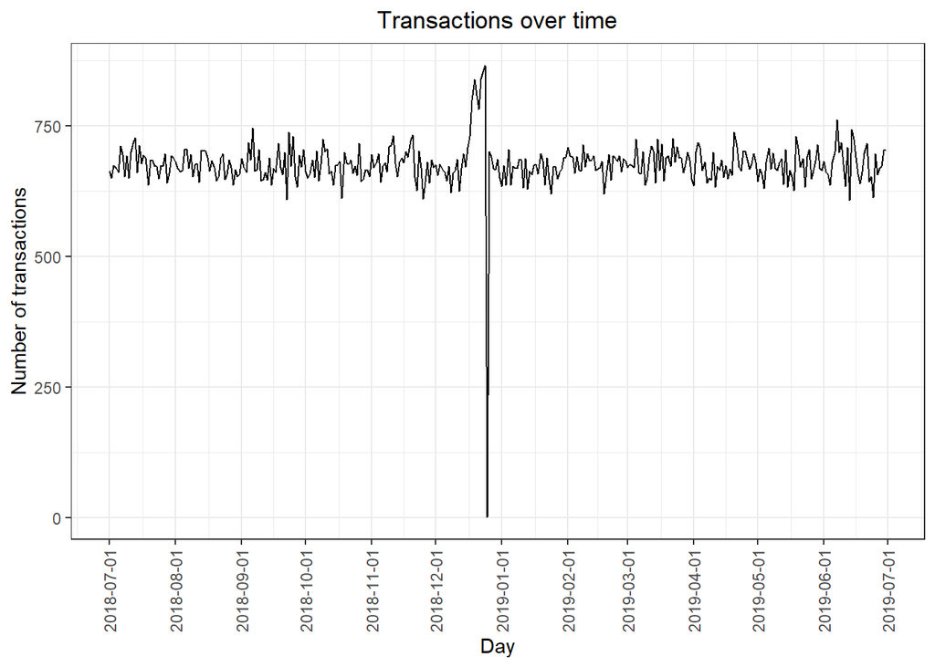

```r
theme_set(theme_bw())
theme_update(plot.title = element_text(hjust = 0.5))
#### Plot transactions over time
mydata %>%
  count(DATE) %>%
  ggplot(aes(x = DATE, y = n)) +
   geom_line() +
 labs(x = "Day", y = "Number of transactions", title = "Transactions over time") +
 scale_x_date(breaks = "1 month") +
 theme(axis.text.x = element_text(angle = 90, vjust = 0.5))
```

We can see that there is an increase in purchases in December and a break in late December. Let’s zoom in on this.

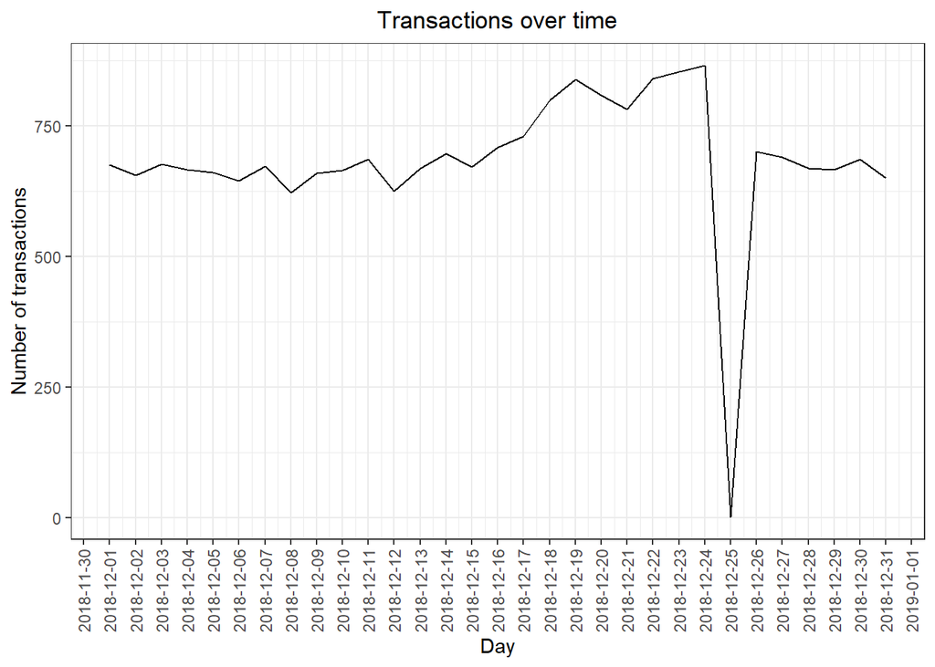

```r
mydata %>%
  filter(between(DATE, "2018-12-01","2018-12-31")) %>%
  count(DATE) %>%
   ggplot(aes(x = DATE, y = n)) +
   geom_line() +
 labs(x = "Day", y = "Number of transactions", title = "Transactions over time") +
 scale_x_date(breaks = "1 day") +
 theme(axis.text.x = element_text(angle = 90, vjust = 0.5))
```

```r
transaction_data<-transaction_data %>%
  mutate(PACK_SIZE_grams= parse_number(PROD_NAME))
  head(transaction_data)
```

| DATE | STORE_NBR | LYLTY_CARD_NBR | TXN_ID | PROD_NBR | PROD_NAME | PROD_QTY | TOT_SALES | PACK_SIZE_grams |
| --- | --- | --- | --- | --- | --- | --- | --- | --- |
| 2018-10-17 | 1 | 1000 | 1 | 5 | Natural Chip Compny SeaSalt175g | 2 | 6.0 | 175 |
| 2019-05-14 | 1 | 1307 | 348 | 66 | CCs Nacho Cheese 175g | 3 | 6.3 | 175 |
| 2019-05-20 | 1 | 1343 | 383 | 61 | Smiths Crinkle Cut Chips Chicken 170g | 2 | 2.9 | 170 |
| 2018-08-17 | 2 | 2373 | 974 | 69 | Smiths Chip Thinly S/Cream&Onion 175g | 5 | 15.0 | 175 |
| 2018-08-18 | 2 | 2426 | 1038 | 108 | Kettle Tortilla ChpsHny&Jlpno Chili 150g | 3 | 13.8 | 150 |
| 2019-05-16 | 4 | 4149 | 3333 | 16 | Smiths Crinkle Chips Salt & Vinegar 330g | 1 | 5.7 | 330 |

```r
summary(transaction_data$PACK_SIZE_grams)
```

```
##    Min. 1st Qu.  Median    Mean 3rd Qu.    Max.
##    70.0   150.0   170.0   175.6   175.0   380.0
```

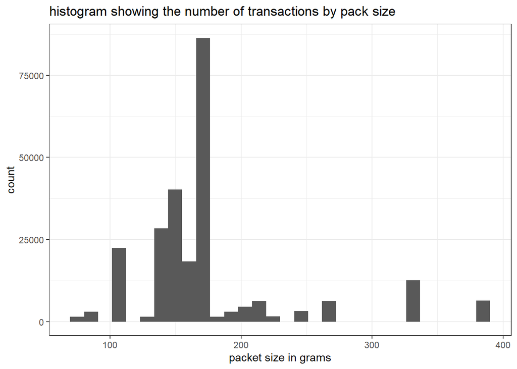

```r
transaction_data %>%
  ggplot(aes(PACK_SIZE_grams))+
  geom_histogram()+
  labs(title = "histogram showing the number of transactions by pack size",
       x="packet size in grams")+
  theme_bw()
```

```r
view(transaction_data$PROD_NAME)
```

Now to create brands, we can use the first word in PROD_NAME to work out the brand name.

```r
transaction_data<-transaction_data %>%
  mutate(brand=str_extract(PROD_NAME,"\\b\\w+"))
head(transaction_data)
```

| DATE | STORE_NBR | LYLTY_CARD_NBR | TXN_ID | PROD_NBR | PROD_NAME | PROD_QTY | TOT_SALES | PACK_SIZE_grams | brand |
| --- | --- | --- | --- | --- | --- | --- | --- | --- | --- |
| 2018-10-17 | 1 | 1000 | 1 | 5 | Natural Chip Compny SeaSalt175g | 2 | 6.0 | 175 | Natural |
| 2019-05-14 | 1 | 1307 | 348 | 66 | CCs Nacho Cheese 175g | 3 | 6.3 | 175 | CCs |
| 2019-05-20 | 1 | 1343 | 383 | 61 | Smiths Crinkle Cut Chips Chicken 170g | 2 | 2.9 | 170 | Smiths |
| 2018-08-17 | 2 | 2373 | 974 | 69 | Smiths Chip Thinly S/Cream&Onion 175g | 5 | 15.0 | 175 | Smiths |
| 2018-08-18 | 2 | 2426 | 1038 | 108 | Kettle Tortilla ChpsHny&Jlpno Chili 150g | 3 | 13.8 | 150 | Kettle |
| 2019-05-16 | 4 | 4149 | 3333 | 16 | Smiths Crinkle Chips Salt & Vinegar 330g | 1 | 5.7 | 330 | Smiths |

```r
as.data.frame(table(transaction_data$brand))
```

| Var1 | Freq |
| --- | --- |
| Burger | 1564 |
| CCs | 4551 |
| Cheetos | 2927 |
| Cheezels | 4603 |
| Cobs | 9693 |
| Dorito | 3183 |
| Doritos | 22041 |
| French | 1418 |
| Grain | 6272 |
| GrnWves | 1468 |

[output cut: 18 more lines]

Some of the brand names look like they are of the same brands - such as RED and RRD, which are both Red Rock Deli chips. Let’s combine these together.

```r
dt<-as.data.table(transaction_data)
is.data.table(dt)
```

```
## [1] TRUE
```

```r
dt[brand== "RED", brand:= "RRD"]
```

purchase_behaviour

```r
head(purchase_behaviour)
```

|  | LYLTY_CARD_NBR | LIFESTAGE | PREMIUM_CUSTOMER |
| --- | --- | --- | --- |
| 1 | 1000 | YOUNG SINGLES/COUPLES | Premium |
| 2 | 1002 | YOUNG SINGLES/COUPLES | Mainstream |
| 3 | 1003 | YOUNG FAMILIES | Budget |
| 4 | 1004 | OLDER SINGLES/COUPLES | Mainstream |
| 5 | 1005 | MIDAGE SINGLES/COUPLES | Mainstream |
| 6 | 1007 | YOUNG SINGLES/COUPLES | Budget |

```r
summary(purchase_behaviour)
```

```
##  LYLTY_CARD_NBR     LIFESTAGE         PREMIUM_CUSTOMER
##  Min.   :   1000   Length:72637       Length:72637
##  1st Qu.:  66202   Class :character   Class :character
##  Median : 134040   Mode  :character   Mode  :character
##  Mean   : 136186
##  3rd Qu.: 203375
##  Max.   :2373711
```

```r
as.data.frame(table(purchase_behaviour$LIFESTAGE))
```

| Var1 | Freq |
| --- | --- |
| MIDAGE SINGLES/COUPLES | 7275 |
| NEW FAMILIES | 2549 |
| OLDER FAMILIES | 9780 |
| OLDER SINGLES/COUPLES | 14609 |
| RETIREES | 14805 |
| YOUNG FAMILIES | 9178 |
| YOUNG SINGLES/COUPLES | 14441 |

```r
as.data.frame(table(purchase_behaviour$PREMIUM_CUSTOMER))
```

| Var1 | Freq |
| --- | --- |
| Budget | 24470 |
| Mainstream | 29245 |
| Premium | 18922 |

Merge transaction data to customer data

```r
data <- merge(transaction_data,purchase_behaviour, all.x = TRUE)
```

```r
head(data)
```

|  | LYLTY_CARD_NBR | DATE | STORE_NBR | TXN_ID | PROD_NBR | PROD_NAME | PROD_QTY | TOT_SALES | PACK_SIZE_grams | brand | LIFESTAGE | PREMIUM_CUSTOMER |
| --- | --- | --- | --- | --- | --- | --- | --- | --- | --- | --- | --- | --- |
| 1 | 1000 | 2018-10-17 | 1 | 1 | 5 | Natural Chip Compny SeaSalt175g | 2 | 6.0 | 175 | Natural | YOUNG SINGLES/COUPLES | Premium |
| 2 | 1002 | 2018-09-16 | 1 | 2 | 58 | Red Rock Deli Chikn&Garlic Aioli 150g | 1 | 2.7 | 150 | Red | YOUNG SINGLES/COUPLES | Mainstream |
| 3 | 1003 | 2019-03-08 | 1 | 4 | 106 | Natural ChipCo Hony Soy Chckn175g | 1 | 3.0 | 175 | Natural | YOUNG FAMILIES | Budget |
| 4 | 1003 | 2019-03-07 | 1 | 3 | 52 | Grain Waves Sour Cream&Chives 210G | 1 | 3.6 | 210 | Grain | YOUNG FAMILIES | Budget |
| 5 | 1004 | 2018-11-02 | 1 | 5 | 96 | WW Original Stacked Chips 160g | 1 | 1.9 | 160 | WW | OLDER SINGLES/COUPLES | Mainstream |
| 6 | 1005 | 2018-12-28 | 1 | 6 | 86 | Cheetos Puffs 165g | 1 | 2.8 | 165 | Cheetos | MIDAGE SINGLES/COUPLES | Mainstream |

check for null

```r
table(is.null(data))
```

```
##
## FALSE
##     1
```

data save for work two

```r
fwrite(data, paste0("C:/Users/morisky/Desktop/quantium/work1","QVI_data.csv"))
```

## Data analysis on customer segments

Now that the data is ready for analysis, we can define some metrics of interest to the client: • Who spends the most on chips (total sales), describing customers by lifestage and how premium their general purchasing behaviour is • How many customers are in each segment • How many chips are bought per customer by segment • What’s the average chip price by customer segment We could also ask our data team for more information. Examples are: • The customer’s total spend over the period and total spend for each transaction to understand what proportion of their grocery spend is on chips • Proportion of customers in each customer segment overall to compare against the mix of customerswho purchase chips Let’s start with calculating total sales by LIFESTAGE and PREMIUM_CUSTOMER and plotting the split by these segments to describe which customer segment contribute most to chip sales.

#### 1. Total sales by LIFESTAGE and PREMIUM_CUSTOMER

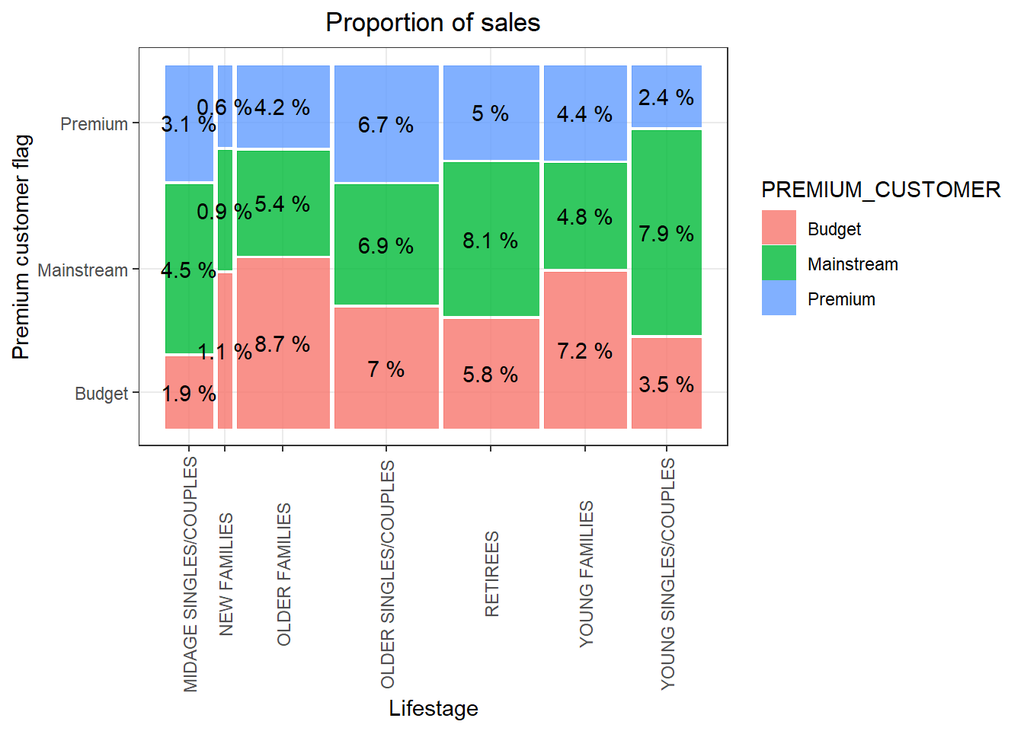

```r
sales<-data %>%
  select(LIFESTAGE,PREMIUM_CUSTOMER, TOT_SALES) %>%
  mutate(SALES = sum(TOT_SALES))
#### Create plot
p <- ggplot(data = sales) +
geom_mosaic(aes(weight = SALES, x = product(PREMIUM_CUSTOMER, LIFESTAGE),
fill = PREMIUM_CUSTOMER)) +
labs(x = "Lifestage", y = "Premium customer flag", title = "Proportion of sales") +
theme(axis.text.x = element_text(angle = 90, vjust = 0.5))
#### Plot and label with proportion of sales
p +
  geom_text(data = ggplot_build(p)$data[[1]], aes(x = (xmin + xmax)/2 , y =
(ymin + ymax)/2, label = as.character(paste(round(.wt/sum(.wt),3)*100,
'%'))))
```

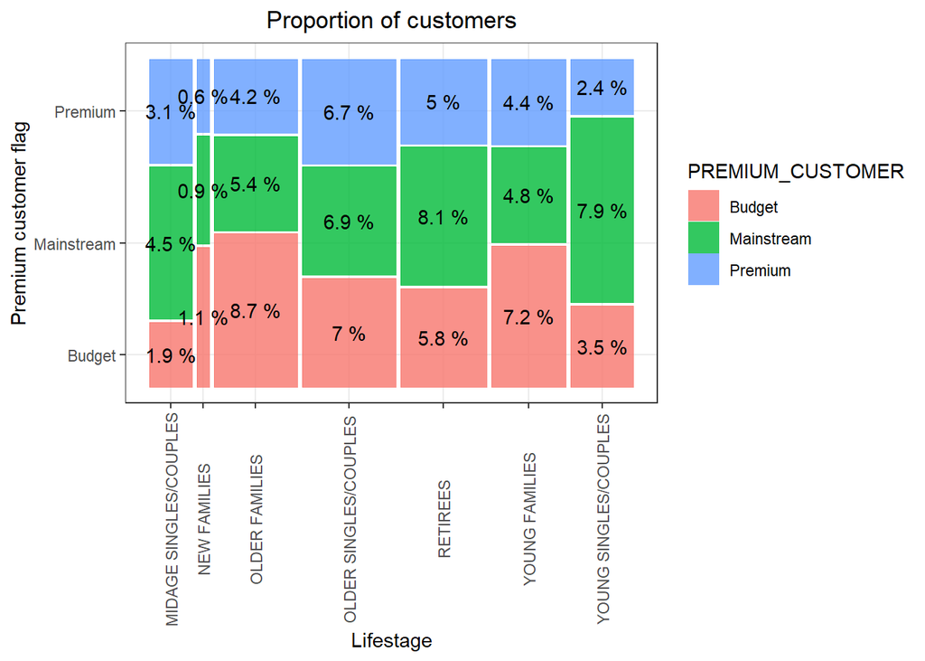

```r
customers <- data %>%
  mutate(CUSTOMERS = uniqueN(LYLTY_CARD_NBR)) %>%
  select(LIFESTAGE,PREMIUM_CUSTOMER,CUSTOMERS)
#### Create plot
p <- ggplot(data = customers) +
geom_mosaic(aes(weight = CUSTOMERS, x = product(PREMIUM_CUSTOMER,
LIFESTAGE), fill = PREMIUM_CUSTOMER)) +
labs(x = "Lifestage", y = "Premium customer flag", title = "Proportion of customers") +
theme(axis.text.x = element_text(angle = 90, vjust = 0.5))
#### Plot and label with proportion of customers
p + geom_text(data = ggplot_build(p)$data[[1]], aes(x = (xmin + xmax)/2 , y =
(ymin + ymax)/2, label = as.character(paste(round(.wt/sum(.wt),3)*100,
'%'))))
```

####3. Average price per unit by LIFESTAGE and PREMIUM_CUSTOMER

[figure not shown]

```r
#### Average price per unit by LIFESTAGE and PREMIUM_CUSTOMER
avg_price <- data %>%
  mutate(AVG = sum(TOT_SALES)/sum(PROD_QTY)) %>%
  arrange(desc(-AVG))
#### Create plot
ggplot(data = avg_price, aes(weight = AVG, x = LIFESTAGE, fill =PREMIUM_CUSTOMER)) +
geom_bar(position = position_dodge()) +
labs(x = "Lifestage", y = "Avg price per unit", title = "Price per unit") +
theme(axis.text.x = element_text(angle = 90, vjust = 0.5))
```

```r
data<- as.data.table(data)
pricePerUnit <- data[, price := TOT_SALES/PROD_QTY]
t.test(data[LIFESTAGE %in% c("YOUNG SINGLES/COUPLES", "MIDAGE SINGLES/COUPLES") &
              PREMIUM_CUSTOMER == "Mainstream", price],
       data[LIFESTAGE %in% c("YOUNG SINGLES/COUPLES", "MIDAGE SINGLES/COUPLES") &
              PREMIUM_CUSTOMER != "Mainstream", price]
       , alternative = "greater")
```

```
##
##  Welch Two Sample t-test
##
## data:  data[LIFESTAGE %in% c("YOUNG SINGLES/COUPLES", "MIDAGE SINGLES/COUPLES") & PREMIUM_CUSTOMER == "Mainstream", price] and data[LIFESTAGE %in% c("YOUNG SINGLES/COUPLES", "MIDAGE SINGLES/COUPLES") & PREMIUM_CUSTOMER != "Mainstream", price]
## t = 37.624, df = 54791, p-value < 2.2e-16
## alternative hypothesis: true difference in means is greater than 0
## 95 percent confidence interval:
##  0.3187234       Inf
## sample estimates:
## mean of x mean of y
##  4.039786  3.706491
```

The t-test results in a p-value < 2.2e-16, i.e. the unit price for mainstream, young and mid-age singles and couples are significantly higher than that of budget or premium, young and midage singles and couples.

#### Deep dive into Mainstream, young singles/couples

```r
#### Deep dive into Mainstream, young singles/couples
segment1 <- data[LIFESTAGE == "YOUNG SINGLES/COUPLES" & PREMIUM_CUSTOMER =="Mainstream",]
other <- data[!(LIFESTAGE == "YOUNG SINGLES/COUPLES" & PREMIUM_CUSTOMER =="Mainstream"),]
#### Brand affinity compared to the rest of the population
quantity_segment1 <- segment1[, sum(PROD_QTY)]
quantity_other <- other[, sum(PROD_QTY)]
quantity_segment1_by_brand <- segment1[, .(targetSegment =sum(PROD_QTY)/quantity_segment1),
                                       by = brand]
quantity_other_by_brand <- other[, .(other = sum(PROD_QTY)/quantity_other), by= brand]
brand_proportions <- merge(quantity_segment1_by_brand,
                           quantity_other_by_brand)[, affinityToBrand :=
                                                      targetSegment/other]

brand_proportions[order(-affinityToBrand)]
```

| brand | targetSegment | other | affinityToBrand |
| --- | --- | --- | --- |
| Dorito | 0.015707384 | 0.012759861 | 1.2309996 |
| Tyrrells | 0.031552795 | 0.025692464 | 1.2280953 |
| Twisties | 0.046183575 | 0.037876520 | 1.2193194 |
| Doritos | 0.107053140 | 0.088314823 | 1.2121764 |
| Kettle | 0.197984817 | 0.165553442 | 1.1958967 |
| Tostitos | 0.045410628 | 0.037977861 | 1.1957131 |
| Infzns | 0.014934438 | 0.012573300 | 1.1877898 |
| Pringles | 0.119420290 | 0.100634769 | 1.1866703 |
| Grain | 0.029123533 | 0.025121265 | 1.1593180 |
| Cobs | 0.044637681 | 0.039048861 | 1.1431238 |

[output cut: 18 more lines]

We can see that : • Mainstream young singles/couples are 23% more likely to purchase Tyrrells chips compared to the rest of the population • Mainstream young singles/couples are 56% less likely to purchase Burger Rings compared to the rest of the population Let’s also find out if our target segment tends to buy larger packs of chips.

```r
quantity_segment1_by_pack <- segment1[, .(targetSegment =sum(PROD_QTY)/quantity_segment1),
                                      by = PACK_SIZE_grams]
quantity_other_by_pack <- other[, .(other = sum(PROD_QTY)/quantity_other),
                                by=PACK_SIZE_grams]
pack_proportions <- merge(quantity_segment1_by_pack,
                          quantity_other_by_pack)[,affinityToPack := targetSegment/other]
pack_proportions[order(-affinityToPack)]
```

| PACK_SIZE_grams | targetSegment | other | affinityToPack |
| --- | --- | --- | --- |
| 270 | 0.031828847 | 0.025095929 | 1.2682873 |
| 380 | 0.032160110 | 0.025584213 | 1.2570295 |
| 330 | 0.061283644 | 0.050161917 | 1.2217166 |
| 134 | 0.119420290 | 0.100634769 | 1.1866703 |
| 110 | 0.106280193 | 0.089791190 | 1.1836372 |
| 210 | 0.029123533 | 0.025121265 | 1.1593180 |
| 135 | 0.014768806 | 0.013075403 | 1.1295106 |
| 250 | 0.014354727 | 0.012780590 | 1.1231662 |
| 170 | 0.080772947 | 0.080985964 | 0.9973697 |
| 150 | 0.157598344 | 0.163420656 | 0.9643722 |

[output cut: 10 more lines]

```r
data[PACK_SIZE_grams == 270, unique(PROD_NAME)]
```

```
## [1] "Twisties Cheese     270g" "Twisties Chicken270g"
```